# Bike Data

MaxClef

### How do annual members and casual riders use Cyclistic bikes differently?

Importing libraries

**Based on all the information found while working with the data in SQL, I decided to import:**

- data that includes only `classic_bike` and `electric_bike`

Connecting to the database/getting the data

```r
con <- dbConnect(RPostgres::Postgres(),
                 dbname = 'divvy-tripdata',
                 host = "localhost",
                 port = 5432,
                 user = "postgres",
                 password = getPass())
```

```
## Please enter password in TK window (Alt+Tab)
```

```r
query = "
  SELECT
    m.member_type,
    b.bike_type,
    s1.station_name AS start_station_name,
    s2.station_name AS end_station_name,
    t.duration_minutes,
    t.started_at AS started_time,
    t.ended_at AS ended_time,
    t.distance_meters,
    t.start_lat,
    t.start_lng,
    t.end_lat,
    t.end_lng
  FROM
    trip_data_past_year t
      JOIN member_types m
          ON t.member_type_id = m.id
      JOIN bikes b
          ON t.bike_type_id = b.id
      JOIN station_names s1
          ON t.start_station_name_id = s1.id
      JOIN station_names s2
          ON t.end_station_name_id = s2.id
  WHERE b.bike_type IN ('classic_bike', 'electric_bike');
"

data <- dbGetQuery(con, query)

dbDisconnect(con)
```

Checking the retrieved data

```r
str(data)
```

```
## 'data.frame':    4179035 obs. of  12 variables:
##  $ member_type       : chr  "casual" "member" "casual" "member" ...
##  $ bike_type         : chr  "classic_bike" "electric_bike" "classic_bike" "classic_bike" ...
##  $ start_station_name: chr  "Shedd Aquarium" "Avers Ave & Belmont Ave" "Adler Planetarium" "Stockton Dr & Wrightwood Ave" ...
##  $ end_station_name  : chr  "Theater on the Lake" "Kenosha & Wellington" "Adler Planetarium" "Clark St & Lincoln Ave" ...
##  $ duration_minutes  : num  136.3 5.12 84.88 7.07 19.73 ...
##  $ started_time      : POSIXct, format: "2022-07-23 08:20:17" "2022-05-25 19:22:15" ...
##  $ ended_time        : POSIXct, format: "2022-07-23 10:36:35" "2022-05-25 19:27:22" ...
##  $ distance_meters   : num  6698 1173 0 1774 3905 ...
##  $ start_lat         : num  41.9 41.9 41.9 41.9 41.9 ...
##  $ start_lng         : num  -87.6 -87.7 -87.6 -87.6 -87.6 ...
##  $ end_lat           : num  41.9 41.9 41.9 41.9 41.9 ...
##  $ end_lng           : num  -87.6 -87.7 -87.6 -87.6 -87.7 ...
```

Splitting columns `started_time` and `ended_time` into:

- year - for year (e.g., 2022)
- month - for month (e.g., August)
- day - for day of the week (e.g., Monday)

```r
data$year <- format(data$started_time, "%Y")

data$month <- format(data$started_time, "%B")

data$day <- format(data$started_time, "%A")
```

Converting `month` and `day` into factors (when plotting they will be orgered correctlly)

```r
data$month <- factor(data$month,
                     levels = c("October", "November", "December", "January",
                                "February", "March", "April", "May", "June",
                                "July", "August", "September"))
data$day <- factor(data$day,
                   levels = c("Monday", "Tuesday", "Wednesday", "Thursday",
                              "Friday", "Saturday", "Sunday"))
```

Checking mutated datarfame

```r
str(data)
```

```
## 'data.frame':    4179035 obs. of  15 variables:
##  $ member_type       : chr  "casual" "member" "casual" "member" ...
##  $ bike_type         : chr  "classic_bike" "electric_bike" "classic_bike" "classic_bike" ...
##  $ start_station_name: chr  "Shedd Aquarium" "Avers Ave & Belmont Ave" "Adler Planetarium" "Stockton Dr & Wrightwood Ave" ...
##  $ end_station_name  : chr  "Theater on the Lake" "Kenosha & Wellington" "Adler Planetarium" "Clark St & Lincoln Ave" ...
##  $ duration_minutes  : num  136.3 5.12 84.88 7.07 19.73 ...
##  $ started_time      : POSIXct, format: "2022-07-23 08:20:17" "2022-05-25 19:22:15" ...
##  $ ended_time        : POSIXct, format: "2022-07-23 10:36:35" "2022-05-25 19:27:22" ...
##  $ distance_meters   : num  6698 1173 0 1774 3905 ...
##  $ start_lat         : num  41.9 41.9 41.9 41.9 41.9 ...
##  $ start_lng         : num  -87.6 -87.7 -87.6 -87.6 -87.6 ...
##  $ end_lat           : num  41.9 41.9 41.9 41.9 41.9 ...
##  $ end_lng           : num  -87.6 -87.7 -87.6 -87.6 -87.7 ...
##  $ year              : chr  "2022" "2022" "2022" "2022" ...
##  $ month             : Factor w/ 12 levels "October","November",..: 10 8 8 9 10 2 1 12 10 10 ...
##  $ day               : Factor w/ 7 levels "Monday","Tuesday",..: 6 3 1 6 7 2 7 7 6 5 ...
```

Checking the number of missing values in each column

```r
colSums(is.na(data))
```

```
##        member_type          bike_type start_station_name   end_station_name
##                  0                  0                  0                  0
##   duration_minutes       started_time         ended_time    distance_meters
##                  0                  0                  0                  0
##          start_lat          start_lng            end_lat            end_lng
##                  0                  0                  0                  0
##               year              month                day
##                  0                  0                  0
```

No missing values are present

### Checking for Inconsitencies

Visualizing `duration_minuts`

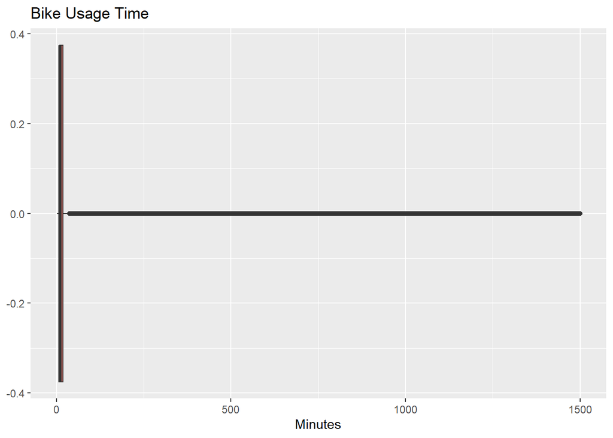

```r
ggplot(data) +
  geom_boxplot(aes(x = duration_minutes, fill = "#0c4c8a")) +
  labs( title = "Bike Usage Time", x = "Minutes") +
  theme( legend.position = "none")
```

Percentiles

```r
quantile(data$duration_minutes)
```

```
##      0%     25%     50%     75%    100%
##    1.00    6.32   10.70   18.65 1499.90
```

Descriptive statistics for `duration_minuts`

```r
psych::describe(data$duration_minutes)
```

```
##    vars       n  mean    sd median trimmed  mad min    max  range  skew
## X1    1 4179035 16.26 26.85   10.7   12.49 7.86   1 1499.9 1498.9 21.65
##    kurtosis   se
## X1   812.18 0.01
```

Looking at the maximum duration for 95% of the time

```r
upper_bound <- quantile(data$duration_minutes, 0.95)
upper_bound
```

```
##   95%
## 43.72
```

It’s clear that variable `duration_minutes` is right skewed based on the mean (16.26) and trimmed mean (12.49)

I doubt there are people that use the bikes for up to 1000+ minutes (16+ hours)

Even if they do these are clear outliers, I mean the pricing is steep:

- members :
  - classic bikes ($119 per year):
    - unlocking the bike - free
    - usage - free 45 minutes at a time
    - over 45 minutes is $0.16 per minute
  - electric bikes ($119 per year)

    -unlocking the bike - free
    - usage - $0.16 per minute
    - parking has extra charges based on location
- casual:
  - classic bikes:
    - unlocking the bike - $1
    - usage - $0.16 per minute
  - electric bikes

    -unlocking the bike - $1
    - usage - $0.39 per minute
    - parking has extra charges based on location

There is also a third category of users which are casual members that get a `daily pass`. They have 3 hours of free rides for 24 hours for classic bikes.

Sources [here](https://divvybikes.com/pricing) and [here](https://divvybikes.com/pricing/ebikes)

The battery of an electric bike lasts maximum for 60 miles. If we assume that the person rides one non-stop at a maximum speed of 3 hours, thay have enough battery only for 3 hours.

Source [here](https://ride.divvybikes.com/blog/new-divvy-ebike#:~:text=Longer%20rides%3A%20We've%20increased,operations%20trips%20to%20replace%20batteries.)

Based on all of the above I decided to remove all that have a duration above 43.72 minutes. Meaning, removing 5% (208,951 values) from the data.

```r
clean_data <- data %>% filter(duration_minutes <= 43.72 )
```

Visualizing cleaned data

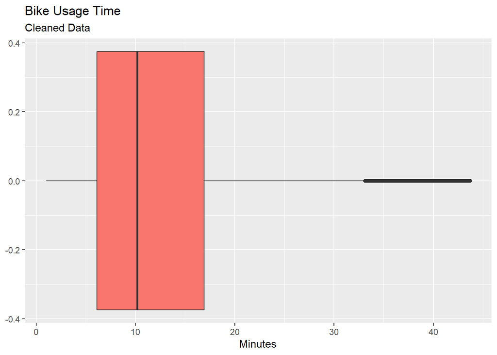

```r
ggplot(clean_data) +
  geom_boxplot(aes(x = duration_minutes, fill = "#0c4c8a")) +
  labs( title = "Bike Usage Time", x = "Minutes",
        subtitle = "Cleaned Data") +
  theme( legend.position = "none")
```

### 1. How do annual members and casual riders use Cyclistic bikes differently?

**Difference in time usage by group**

Visualizing duration by group and bike type

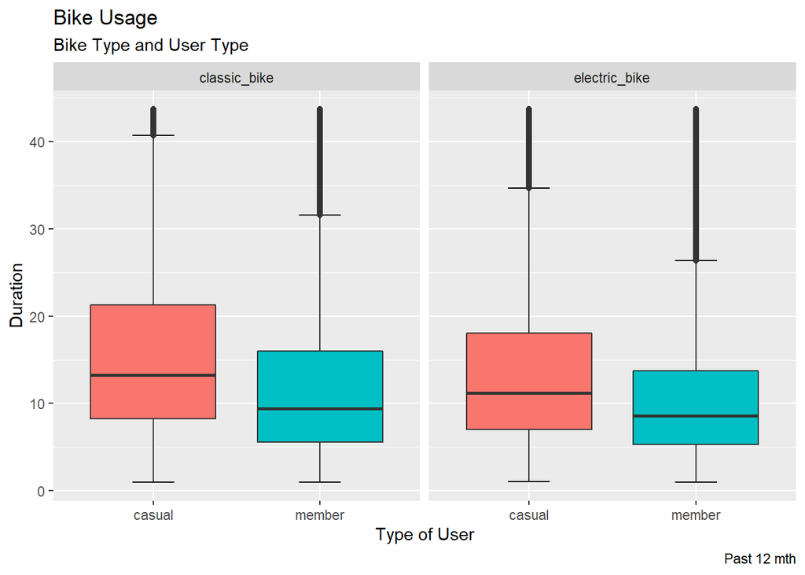

```r
ggplot(clean_data, aes(x = member_type, y = duration_minutes, fill = member_type)) +
  stat_boxplot(geom = "errorbar", width = 0.25) +
  geom_boxplot() +
  labs(title = "Bike Usage", subtitle = "Bike Type and User Type", caption = "Past 12 mth",
      x = "Type of User", y =  "Duration") +
  theme(legend.position = "none") +
  facet_wrap(~bike_type)
```

Mean for each group by usage of bike type

```r
clean_data %>% group_by(member_type, bike_type) %>% summarise_at(vars(duration_minutes),
                                                           list(mean = "mean"))
```

```
## # A tibble: 4 x 3
## # Groups:   member_type [2]
##   member_type bike_type      mean
##   <chr>       <chr>         <dbl>
## 1 casual      classic_bike   15.8
## 2 casual      electric_bike  13.7
## 3 member      classic_bike   12.1
## 4 member      electric_bike  10.6
```

Looks like on average casual users tend to use the bikes for a longer period of time.

**Bike usage by month for each group**

Plot the difference in usage of bikes by month

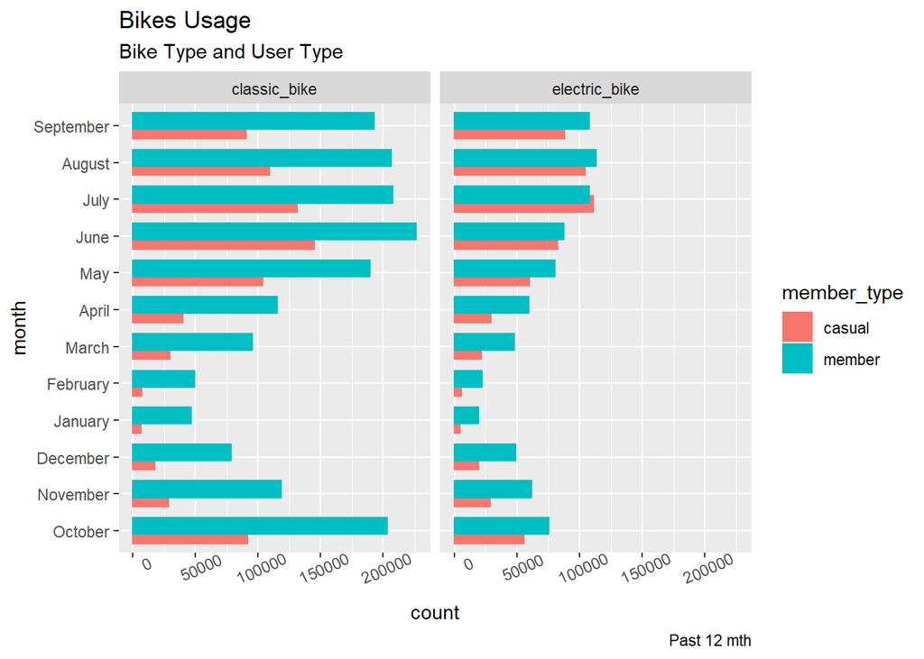

```r
ggplot(clean_data) +
  geom_bar(aes(x = month, fill = member_type, color = member_type), position = position_dodge(width=0.5)) +
  coord_flip() +
  labs(title = "Bikes Usage", subtitle = "Bike Type and User Type", caption = "Past 12 mth") +
  theme(axis.text.x = element_text(angle=25)) +
  scale_y_continuous(labels = function(x) format(x, scientific = FALSE)) +
  facet_wrap(~bike_type)
```

Based on the plot above we see that the only time when the casual users use the services more than the members is in the month of July for electric bikes.Potentially because of summer tourists.

Another factor for bike usages could be the weather.

Casual users contingency table by month and type of bike percentage

```r
casual_users <- clean_data %>% filter(member_type == "casual")
c_table <- prop.table(table(casual_users$bike_type, casual_users$month)) * 100
addmargins(round(c_table, 2))
```

```
##
##                 October November December January February  March  April    May
##   classic_bike     6.48     2.01     1.25    0.44     0.50   2.08   2.83   7.35
##   electric_bike    3.96     2.03     1.38    0.33     0.39   1.51   2.09   4.26
##   Sum             10.44     4.04     2.63    0.77     0.89   3.59   4.92  11.61
##
##                   June   July August September    Sum
##   classic_bike   10.26   9.30   7.75      6.43  56.68
##   electric_bike   5.85   7.88   7.41      6.24  43.33
##   Sum            16.11  17.18  15.16     12.67 100.01
```

casual users use classic bikes through out the year more often than electric bikes:

- 56.68% using classical bikes usage
- 43.33% using electric bikes usage

With the highest usage of bike in July (17.18%)

Members contingency table by month and type of bike percentage

```r
casual_users <- clean_data %>% filter(member_type == "member")
c_table <- prop.table(table(casual_users$bike_type, casual_users$month)) * 100
addmargins(round(c_table, 2))
```

```
##
##                 October November December January February  March  April    May
##   classic_bike     7.93     4.62     3.07    1.82     1.93   3.74   4.50   7.40
##   electric_bike    2.95     2.41     1.92    0.75     0.87   1.88   2.31   3.13
##   Sum             10.88     7.03     4.99    2.57     2.80   5.62   6.81  10.53
##
##                   June   July August September    Sum
##   classic_bike    8.84   8.10   8.06      7.53  67.54
##   electric_bike   3.41   4.21   4.43      4.20  32.47
##   Sum            12.25  12.31  12.49     11.73 100.01
```

Members are using classic bike though out the year more often than electric once:

- 67.54% classic bikes usage
- 32.47% electric bikes usage

With the highest usage of bikes in August (12.49%)

**Busiest days of each month**

**Casual**

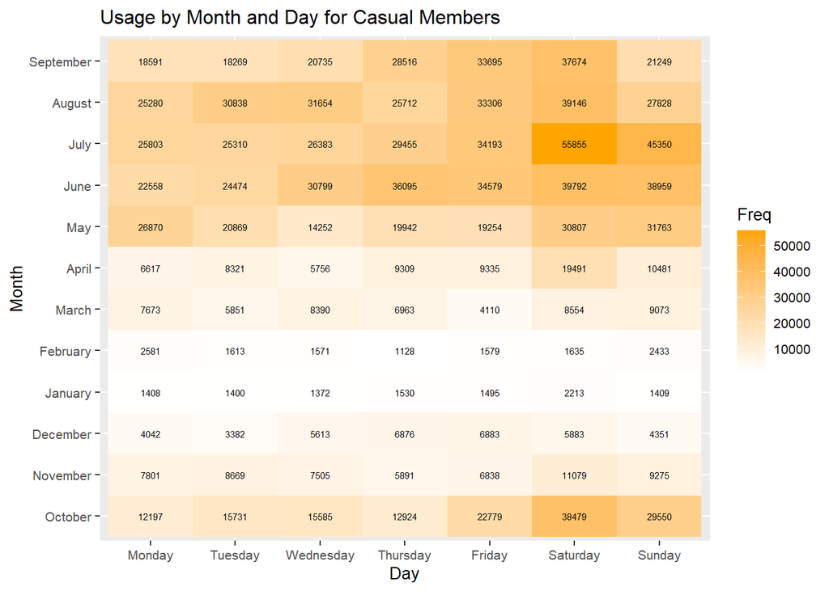

```r
casual <- filter(clean_data, member_type == "casual")
ct_casual <- as.data.frame(table(casual$day, casual$month))

ggplot(ct_casual, aes(x = Var1, y = Var2)) +
  geom_tile(aes(fill = Freq)) +
  geom_text(aes(label = round(Freq, 4)), size = 2) +
  scale_fill_gradient(low = "white", high = "orange") +
  labs(title = "Usage by Month and Day for Casual Members", x = "Day", y =  "Month") +
  theme(text = element_text(size = 10))
```

Casual members have a higher frequency of bike riding on the weekends

**Mabers**

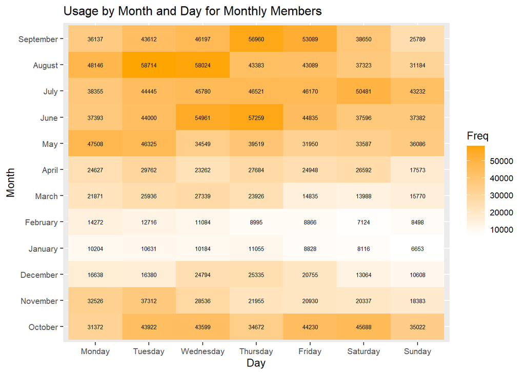

```r
member <- filter(clean_data, member_type == "member")
ct_members <- as.data.frame(table(member$day, member$month))

ggplot(ct_members, aes(x = Var1, y = Var2)) +
  geom_tile(aes(fill = Freq)) +
  geom_text(aes(label = round(Freq, 4)), size = 2) +
  scale_fill_gradient(low = "white", high = "orange") +
  labs(title = "Usage by Month and Day for Monthly Members", x = "Day", y =  "Month") +
  theme(text = element_text(size = 10))
```

Members seem to be biking more often on the week days. Only in July and October members use the bikes more frequently on the weekend (Saturday)

**Top 10 popular starting points by group**

**Casual**

```r
count(casual, start_station_name, sort = T)[1:10, ]
```

```
##                    start_station_name     n
## 1             Streeter Dr & Grand Ave 32450
## 2   DuSable Lake Shore Dr & Monroe St 16961
## 3  DuSable Lake Shore Dr & North Blvd 16220
## 4               Michigan Ave & Oak St 14751
## 5               Wells St & Concord Ln 13740
## 6                     Millennium Park 13367
## 7                 Theater on the Lake 12511
## 8                      Shedd Aquarium 11881
## 9                   Clark St & Elm St 11149
## 10                  Wells St & Elm St 11097
```

**Members**

```r
count(member, start_station_name, sort = T)[1:10, ]
```

```
##              start_station_name     n
## 1      Kingsbury St & Kinzie St 24336
## 2             Clark St & Elm St 21077
## 3         Wells St & Concord Ln 20347
## 4  Clinton St & Washington Blvd 18460
## 5       Clinton St & Madison St 18292
## 6             Wells St & Elm St 17966
## 7      Loomis St & Lexington St 17136
## 8           Ellis Ave & 60th St 16663
## 9      University Ave & 57th St 16293
## 10        Dearborn St & Erie St 16161
```

Exporting data to plot in tableau

```r
data_for_export <- clean_data %>% select(start_lat, start_lng, end_lat, end_lng, month, day)

PATH = "C:/Users/mkcle/Desktop/Coursera/Google Data Analytics/Capstone Project/data"
write.csv(data_for_export, file = paste(PATH, "tableau_file.csv", sep = "/"))
```